# Warm up1

Mingzhuo Pei

1/31/2018

### Game of Thrones

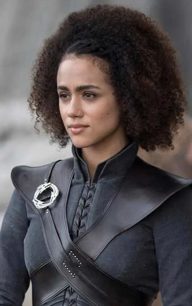

character

| Q | A |
| --- | --- |
| season(s) | 1,2,3,4,5,6,7,8 |
| First seen | “Winter Is Coming” |
| Age | 38 in Season 7 |
| Predecessor | Eddard Stark |
| Successor | Mace Tyrell |
| Status | Alive |
| Allegiance | House Targaryen |

> Missandei: “How many days were you a slave?”

> Tyrion: “Long enough to know.”

> Missandei: “Not long enough to understand.”

### Cooking Recipe

Ingredients: *potatoes *shallots *olive oil *kosher salt *black pepper *Italian sausage *baby arugula *lemon juice

Kitchen tools: *oven *tablespoons *brush *tray *bowl

Steps of the recipe

1.Heat oven to 425°

2.On a large rimmed baking sheet, toss all of the potatoes and shallots with 3 tablespoons olive oil, salt (I use 1 teaspoon kosher), and a lot freshly ground black pepper or red pepper flakes to taste.

3.Roast for 15 minutes, at which they’ll be barely beginning to color.

4.Give them a toss and add sausages.

5.Brush the tops with a little olive oil and return the tray to the oven for another 30 to 40 minutes, until the potatoes are tender and the sausage is cooked through.

6.Transfer everything on the tray to a big bowl and add arugula, lemon juice, and more salt and pepper to taste. Serve right away.

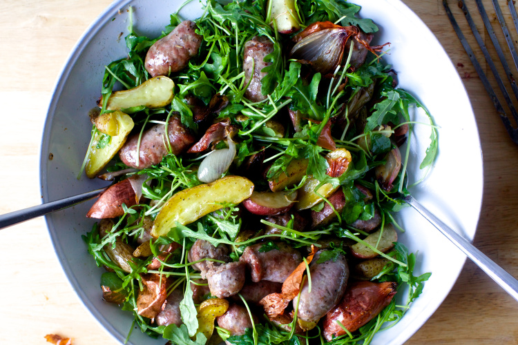

food

**These is no special season of the year for it.**

*No variations of the recipe in this guide*

### Quadratic Equation

In algebra, a quadratic equation (from the Latin quadratus for “square”) is any equation having the form:
$$ax^2+bx+c=0$$
.

The roots of the general quadratic equation:
$$x=\frac{-b\pm\sqrt{b^2-4ac}}{2a}$$

The derivation of the solution:
$$ax^2+bx+c=0$$
$$4a^2x^2+4abx+4ac=0$$
$$4a^2x^2+4abx=-4ac$$
$$4a^2x^2+4abx+b^2=b^2-4ac$$
$$4a^2x^2+4abx+b^2=b^2-4ac$$
$$(2ax+b)^2=b^2-4ac$$
$$2ax=\sqrt{b^2-4ac}$$
$$x=\frac{-b\pm\sqrt{b^2-4ac}}{2a}$$

### Comments and Reflections

1.details

2.follow the tutorial

3.No

4.Yes, I only wrote code in the chunck before. It’s my first time to try this.

5.No.

6.1.5 hour

7.Math mode,the last question.